# Investigating the Relationship Between Covid-19 Vaccinations and New Cases/Deaths

Ewan Clarke-McIntyre 31213898

2023-11-13

```r
knitr::opts_chunk$set(echo = TRUE, warning = FALSE, message = FALSE)
library(tidyverse)
library(ggthemes)
library(naniar)
library(imputeTS)
library(knitr)
covid_raw <- read.csv('data/owid-covid-data.csv')
```

# Problem Description

The COVID-19 pandemic wrought havoc on the world, with approximately 770 million cases and 7 million deaths worldwide. However, the magnitude of these outcomes varied widely throughout the world due to differences in preventative measures such as PPE use, lock-downs, quarantines, and vaccinations. While its effects have been catastrophic, the COVID-19 pandemic has taught us greatly about the spread of infectious respiratory diseases, and the measures that must be employed to control the next pandemic. In particular, it is of the utmost importance to understand the impact of vaccinations on controlling the spread of an infectious disease.

In this analysis I will be investigating the Our World in Data COVID-19 Database (Mathieu et al., 2020) to explore the relationship between COVID-19 vaccinations, new cases, and deaths, in Australia through the following questions:

1. What is the sum of new vaccinations, cases, and deaths by month
2. How the rates of cases and deaths changed over time
3. How the vaccination rate relates to disease outcomes (e.g. cases, deaths)
4. How Australia’s vaccination rate compares to the top 3 countries with the highest number of deaths

# Data Explanation

This dataset has been obtained from the Our World in Data COVID-19 Database (Mathieu et al., 2020). Confirmed cases and deaths have been collected from the World Health Organization Coronavirus Dashboard, hospitalization and vaccination data has been collected by Our World in Data from official medical and government repositories. While COVID reporting occurred daily for many countries during the beginning of the pandemic, as time went on the reporting frequency dropped, resulting in pooled counts for multiple days being reported. This will also explain periods of missing data in this dataset.

This data has been provided as a single .csv file (‘owid-covid-data.csv’) and is available at https://ourworldindata.org/coronavirus

Data summary:

1. Each row represents a single date’s observations for a particular location (country, continent, geographical grouping) across 67 variables
2. These 67 variables include date and location; case, death, vaccination, and hospitalisation data; demographic data including population, age, lifestyle factors, and socioeconomic status; and calculated variables including excess mortality.
3. These variables are presented in both continuous counts, and also ratios, such as total boosters per hundred, and new deaths per million.

# Data Exploration

1. The Our World In Data COVID-19 Database (‘owid-covid-data.csv’) has been loaded into the workspace with the read_csv funciton as covid_raw.
2. Glimpse has been used to explore the structure of the data-set, showing the number of variables, their types, and the total number of observations.
3. We subset the covid_raw dataframe for out columns of interest (“continent”, “location”, “date”, “total_cases”, “new_cases”, “total_deaths”, “new_deaths”, “total_vaccinations”, “new_vaccinations”, “people_fully_vaccinated”, “population”).
4. The date column has been converted from chr format to date format.
5. We then determine the date of the first and last ‘Total Vaccinations’ values for Australia by filtering for observations in Australia, dropping rows in which the ‘Total Vaccinations’ column has NA values, and inspecting the head and tail. We then filter for this date range (2021-02-21 - 2023-03-24) and apply na_interpolation, which uses a linear model to fill missing values.
6. We have mutated our data to include the percentage rate of change of cases/deaths and percentage fully vaccinated have we have mutated our data to add these variables using the total cases, total deaths, and people fully vaccinated/population variables respectively.
7. To determine the top 3 countries with the highest amount of deaths, we group our columns of interest dataset by location (dropping rows for grouped locations e.g. continents), and summarise to find the total cases, deaths, and vaccinations using the max() function. This summary is then arranged in descending order and head(3) is used to determine the top 3 countries with the highest deaths.
8. We then apply similar steps as shown above to filter for the range (2021-02-21 - 2023-03-24), apply na_interpolation, and calculate the percentage of fully vaccinated people.

Following from this, we can generate the following summary: Sum of daily cases, deaths, and vaccinations by month in Australia.

```r
glimpse(covid_raw)
```

```
## Rows: 353,748
## Columns: 67
## $ iso_code                                   <chr> "AFG", "AFG", "AFG", "AFG",…
## $ continent                                  <chr> "Asia", "Asia", "Asia", "As…
## $ location                                   <chr> "Afghanistan", "Afghanistan…
## $ date                                       <chr> "2020-01-03", "2020-01-04",…
## $ total_cases                                <dbl> NA, NA, NA, NA, NA, NA, NA,…
## $ new_cases                                  <dbl> 0, 0, 0, 0, 0, 0, 0, 0, 0, …
## $ new_cases_smoothed                         <dbl> NA, NA, NA, NA, NA, 0, 0, 0…
## $ total_deaths                               <dbl> NA, NA, NA, NA, NA, NA, NA,…
## $ new_deaths                                 <dbl> 0, 0, 0, 0, 0, 0, 0, 0, 0, …
## $ new_deaths_smoothed                        <dbl> NA, NA, NA, NA, NA, 0, 0, 0…
## $ total_cases_per_million                    <dbl> NA, NA, NA, NA, NA, NA, NA,…
## $ new_cases_per_million                      <dbl> 0, 0, 0, 0, 0, 0, 0, 0, 0, …
## $ new_cases_smoothed_per_million             <dbl> NA, NA, NA, NA, NA, 0, 0, 0…
```

[output cut: 54 more lines]

```r
# Subset covid_raw columns of interest
covid_cols_of_interest <- covid_raw[c("continent", "location", "date", "total_cases", "new_cases", "total_deaths", "new_deaths", "total_vaccinations", "new_vaccinations", "people_fully_vaccinated", "population")]

# Australia covid data - summary of observations in columns of interest
covid_summary_australia <- covid_cols_of_interest %>%
  filter(location == "Australia") %>%
  miss_var_summary()
kable(covid_summary_australia, col.names = c("Column", "Missing Values", "Missing Values (%)"), caption = "<b>Summary of Missing Values in Columns of Interest - Australia</b>")
```

**Summary of Missing Values in Columns of Interest - Australia**

| Column | Missing Values | Missing Values (%) |
| --- | --- | --- |
| people_fully_vaccinated | 928 | 66.2857143 |
| new_vaccinations | 868 | 62.0000000 |
| total_vaccinations | 847 | 60.5000000 |
| total_deaths | 59 | 4.2142857 |
| total_cases | 22 | 1.5714286 |
| new_deaths | 1 | 0.0714286 |
| continent | 0 | 0.0000000 |
| location | 0 | 0.0000000 |
| date | 0 | 0.0000000 |
| new_cases | 0 | 0.0000000 |
| population | 0 | 0.0000000 |

```r
# Convert date column into date format
covid_cols_of_interest <- covid_cols_of_interest %>%
  mutate(date = as.Date(date))
```

There are a high number of missing values in columns regarding vaccinations, which is likely due to the time between the start of the pandemic, and the development and rollout of the first vaccine. This will require us to determine the date range in which vaccination data is present.

```r
# Filter for observations from Australia
covid_australia <- covid_cols_of_interest %>%
  filter(location == "Australia")

# find the finding first and last non-na total_vaccination values
covid_australia_na_dropped <- drop_na(covid_australia, total_vaccinations)
first_vaccination <- covid_australia_na_dropped %>%
  head(1)
last_vaccination <- covid_australia_na_dropped %>%
  tail(1)

kable(first_vaccination)
```

| continent | location | date | total_cases | new_cases | total_deaths | new_deaths | total_vaccinations | new_vaccinations | people_fully_vaccinated | population |
| --- | --- | --- | --- | --- | --- | --- | --- | --- | --- | --- |
| Oceania | Australia | 2021-02-21 | 28926 | 6 | 924 | 0 | 20 | NA | NA | 26177410 |

```r
kable(last_vaccination)
```

|  | continent | location | date | total_cases | new_cases | total_deaths | new_deaths | total_vaccinations | new_vaccinations | people_fully_vaccinated | population |
| --- | --- | --- | --- | --- | --- | --- | --- | --- | --- | --- | --- |
| 553 | Oceania | Australia | 2023-03-24 | 11125968 | 0 | 19902 | 0 | 65492360 | NA | 21648824 | 26177410 |

```r
# filter covid_australia for these dates and and impute missing values using a linear interpolation-based method
covid_australia_clean <- covid_australia %>%
  filter(between(date, as.Date('2021-02-21'), as.Date('2023-03-24'))) %>%
  na_interpolation()
```

```r
# group by month and summarise new cases
covid_au_summary <- covid_australia_clean %>%
  group_by(month = floor_date(date, "month")) %>%
  summarise(cases = sum(new_cases),
            deaths = sum(new_deaths),
            vaccinations = sum(new_vaccinations))
kable(covid_au_summary, col.names = c("Month", "New Cases", "New Deaths", "New Vaccinations"), caption = "<b>Summary of Cases, Deaths, and Vaccinations by Month</b>")
```

**Summary of Cases, Deaths, and Vaccinations by Month**

| Month | New Cases | New Deaths | New Vaccinations |
| --- | --- | --- | --- |
| 2021-02-01 | 50 | 0 | 37379 |
| 2021-03-01 | 334 | 2 | 709700 |
| 2021-04-01 | 497 | 2 | 1490514 |
| 2021-05-01 | 305 | 0 | 2127895 |
| 2021-06-01 | 729 | 0 | 3379797 |
| 2021-07-01 | 2960 | 18 | 4591535 |
| 2021-08-01 | 21866 | 102 | 7329051 |
| 2021-09-01 | 48489 | 333 | 8372766 |
| 2021-10-01 | 69834 | 485 | 7567203 |
| 2021-11-01 | 37441 | 311 | 3679863 |
| 2021-12-01 | 155182 | 266 | 3619831 |
| 2022-01-01 | 1956529 | 2113 | 7273456 |
| 2022-02-01 | 693697 | 1529 | 4199217 |
| 2022-03-01 | 1150567 | 661 | 2297185 |
| 2022-04-01 | 1351213 | 1106 | 1212934 |
| 2022-05-01 | 1478635 | 1444 | 1626385 |
| 2022-06-01 | 779787 | 1426 | 1131786 |
| 2022-07-01 | 1138110 | 2190 | 1978162 |
| 2022-08-01 | 782078 | 1998 | 1038357 |
| 2022-09-01 | 195644 | 706 | 633810 |
| 2022-10-01 | 165747 | 477 | 654937 |
| 2022-11-01 | 307187 | 559 | 633810 |
| 2022-12-01 | 419758 | 1164 | 654937 |
| 2023-01-01 | 182324 | 1262 | 654937 |
| 2023-02-01 | 71052 | 598 | 591556 |
| 2023-03-01 | 87033 | 226 | 507048 |

To calculate the percentage rate of change of cases/deaths and percentage fully vaccinated, we have mutated our data to add these variables using the total cases, total deaths, and people fully vaccinated/population variables respectively. This calculation method results in the first row containing missing values, therefore this row will be dropped.

```r
covid_australia_rate_change <- covid_australia_clean %>%
  mutate(cases_change_percentage = ((total_cases - lag(total_cases)) / (lag(total_cases))) * 100) %>%
  mutate(deaths_change_percentage = ((total_deaths - lag(total_deaths)) / (lag(total_deaths))) * 100) %>%
  mutate(percentage_fully_vaccinated = people_fully_vaccinated / population)

# The percentage rate of change calculations will return NA for the first row, due to no previous row being available, thus this row must be dropped
covid_australia_rate_change <- covid_australia_rate_change[-1,]
```

# Data Visualisation

## Australia

To investigate the relationship between vaccinations and the rate of change of cases/deaths, the below bar graphs have been filled based on the percentage of the population who have been fully vaccinated.

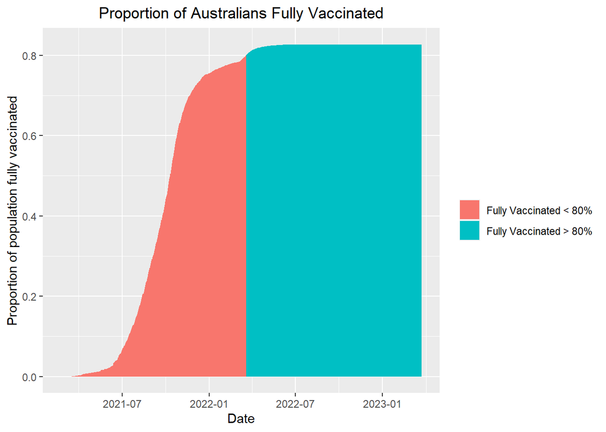

From the above plot, we can see that Australia fully vaccinated ~80% of its population in the middle of March 2022.

```r
# summarise data to get mean case/death change percentage for each month
covid_change_by_month <- covid_australia_rate_change %>%
  group_by(month = floor_date(date, "month")) %>%
  reframe(case_mean_percentage_change = mean(cases_change_percentage),
          death_mean_percentage_change = mean(deaths_change_percentage),
          percentage_fully_vaccinated = percentage_fully_vaccinated)
```

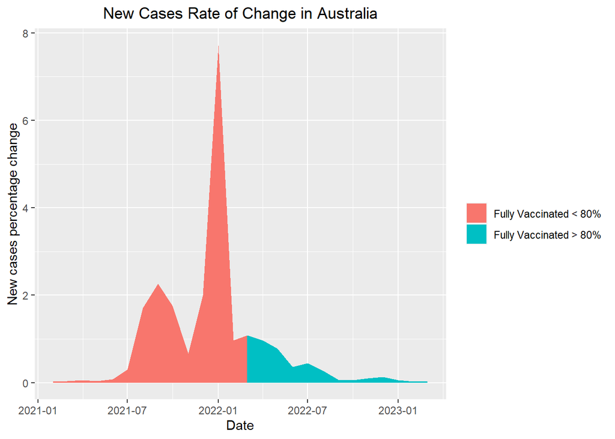

From the plot of the new cases percentage change over time, we can see a clear large peak around the Janurary 2022, followed by a significant dip and low plateau. This plateau correlates quite strongly with Australia reaching ~80% of its population being fully vaccinated.

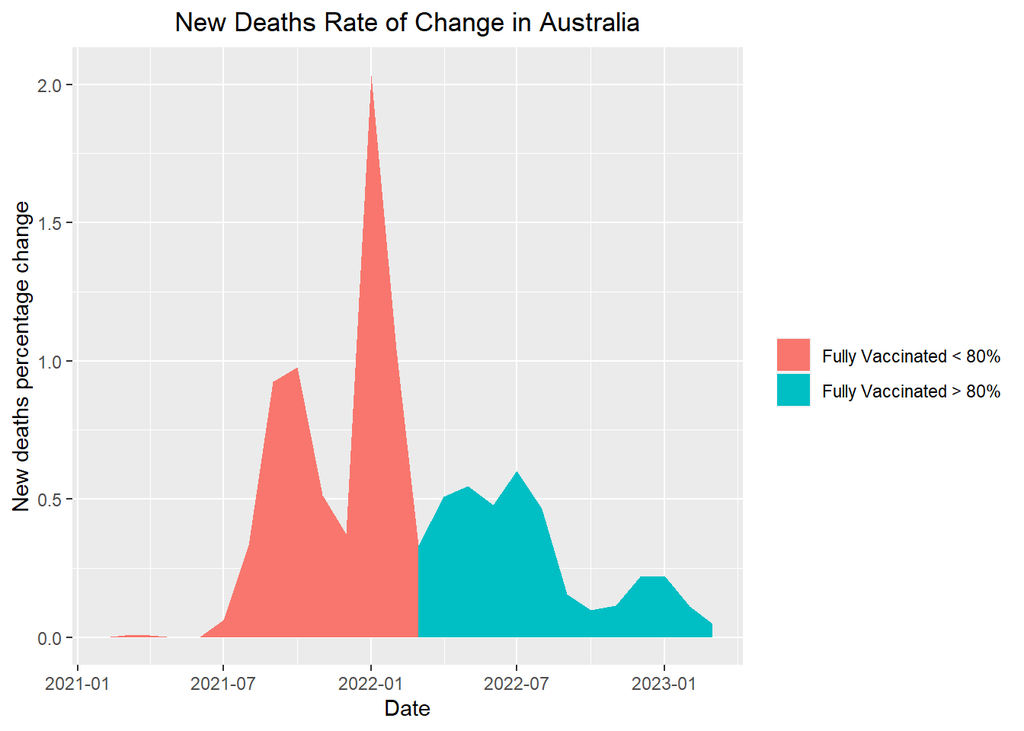

## Top 3 Countries with the Highest Deaths

```r
top_3_highest_deaths <- covid_cols_of_interest %>%
  # removes rows with empty continent value (e.g. composite results such as total continents)
  subset(continent != "") %>%
  group_by(location) %>%
  summarise(total_cases = max(total_cases, na.rm = TRUE),
            total_deaths = max(total_deaths, na.rm = TRUE),
            total_vaccinations = max(total_vaccinations, na.rm = TRUE)) %>%
  arrange(desc(total_deaths)) %>%
  head(3)
kable(top_3_highest_deaths, col.names = c("Country", "Total Cases", "Total Deaths", "Total Vaccinations"), caption = "<b>Top 3 Countries with Highest Number of COVID deaths</b>")
```

**Top 3 Countries with Highest Number of COVID deaths**

| Country | Total Cases | Total Deaths | Total Vaccinations |
| --- | --- | --- | --- |
| United States | 103436829 | 1138309 | 676728782 |
| Brazil | 37721749 | 704659 | 486436436 |
| India | 45001245 | 533293 | 2206748064 |

```r
# filter for top 3 highest death countries and calculate percentage fully vaccinated
top_3_vaccination_percentage <- covid_cols_of_interest %>%
  filter(location == c("United States", "Brazil", "India")) %>%
  mutate(date = as.Date(date)) %>%
  filter(between(date, as.Date('2021-02-21'), as.Date('2023-03-24'))) %>%
  na_interpolation() %>%
  mutate(percentage_fully_vaccinated = people_fully_vaccinated / population)

# The percentage rate of change calculations will return NA for the first row, due to no previous row being available, thus this row must be dropped
top_3_vaccination_percentage <- top_3_vaccination_percentage[-1,]
```

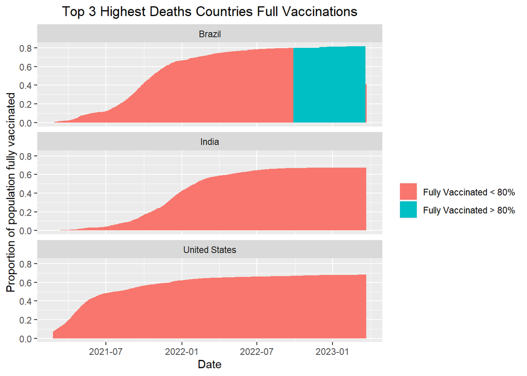

```r
# plot people fully vaccinated
top_3_vaccinations_rate_plot <- top_3_vaccination_percentage %>%
  ggplot() +
  geom_ribbon(aes(x = date, ymin = 0, ymax = percentage_fully_vaccinated, fill = percentage_fully_vaccinated > 0.80)) +
  facet_wrap(~ location, ncol=1) +
  scale_fill_discrete("", labels=c('Fully Vaccinated < 80%', 'Fully Vaccinated > 80%')) +
  xlab("Date") +
  ylab("Proportion of population fully vaccinated") +
  ggtitle("Top 3 Highest Deaths Countries Full Vaccinations") +
  theme(
    plot.title = element_text(hjust = 0.5))
top_3_vaccinations_rate_plot
```